# Introduction to Text Mining

Machine Learning in Economics

Prof. Dr. Hüseyin Taştan

Yildiz Technical University

# 1 Introduction

There are several frameworks for text analysis in R. For a comprehensive list visit the CRAN task force on natural language processing: https://cran.r-project.org/web/views/NaturalLanguageProcessing.html.

Here are some of the widely used packages and frameworks:

- `tm` package: uses DTM object (Term Document Matrix) and provides a general framework for text mining in R. A DTM is a matrix where each row represents a document, each column represents a term and each value includes the number of times that term appears in that document. For more details see the CRAN page: https://cran.r-project.org/web/packages/tm/index.html and the article [Text Mining Infrastructure in R](http://www.jstatsoft.org/v25/i05/)
- `quanteda` package: uses `dfm` object (document feature matrix), see the website https://quanteda.io/.
- `tidytext` package: uses tidyverse principles in analyzing text data. It provides tools for word processing and sentiment analysis. The book Text Mining with R written by Julia Silge and David Robinson uses `tidytext` package and introduces readers to principles of text mining. See the electronic version of the book [Text Mining with R](https://www.tidytextmining.com/index.html). Also visit Julia Silge’s github page: https://github.com/juliasilge/tidytext. Also check out the tutorial by Julia Silge: [Tutorial on Tidytext](https://juliasilge.shinyapps.io/learntidytext/#section-introduction)

In the following, I will use `{tidytext}` package.

# 2 Tidy Text mining

## 2.1 Tidy text data

In a usual tidy data set, each variable is a column and each observation is a row. Similarly, a tidy text data is a table or data frame (tibble) where each row is a token. A **token** is a meaningful unit of text, for example a word. Converting a text data set into tokens is generally known as ‘*tokenization*’. We can use the standart tidyverse tools (`{dplyr}`, `{ggplot2}`, etc.) to analyze tidy text data.

As an example, consider the following text data

```r
# United Nations Universal Declaration of Human Rights 1948
article1 <- c("All human beings are born free and equal in dignity and rights.",
              "They are endowed with reason and conscience and should act towards one another in a spirit of brotherhood.")
article1
```

```
## [1] "All human beings are born free and equal in dignity and rights."
## [2] "They are endowed with reason and conscience and should act towards one another in a spirit of brotherhood."
```

It consists of two rows of characters. Let’s create a tibble using `article1`:

```r
library(tidyverse)
text_data <- tibble(sentence = 1:2,
                    text = article1)
text_data
```

```
## # A tibble: 2 × 2
##   sentence text
##      <int> <chr>
## 1        1 All human beings are born free and equal in dignity and rights.
## 2        2 They are endowed with reason and conscience and should act towards o…
```

Once we have a tibble containing our text data, we can tokenize it based on single words using `tidytext::unnest_tokens()` function.

```r
# you need install and activate the tidytext package
library(tidytext)
#
text_data |>
  unnest_tokens(word, text) # word is output; text is input
```

```
## # A tibble: 30 × 2
##    sentence word
##       <int> <chr>
##  1        1 all
##  2        1 human
##  3        1 beings
##  4        1 are
##  5        1 born
##  6        1 free
##  7        1 and
##  8        1 equal
##  9        1 in
## 10        1 dignity
## # ℹ 20 more rows
```

A **token** can consist of more than one word. These are also known as **n-grams**. An **n-gram** is simply a consecutive sequence of n words. A **bigram**, for example, is a consecutive sequence of two words.

```r
text_data |>
  unnest_tokens(bigram, text, token = "ngrams", n = 2)
```

```
## # A tibble: 28 × 2
##    sentence bigram
##       <int> <chr>
##  1        1 all human
##  2        1 human beings
##  3        1 beings are
##  4        1 are born
##  5        1 born free
##  6        1 free and
##  7        1 and equal
##  8        1 equal in
##  9        1 in dignity
## 10        1 dignity and
## # ℹ 18 more rows
```

Representing a text as list or “bag” of its words without any regard to context and grammar is also known as “bag-of-words” approach.

## 2.2 Frequent Words and Stopwords

Let’s count the words in the text data tibble `text_data`:

```r
text_data_tidy <- text_data |>
                  unnest_tokens(word, text)
# count
text_data_tidy |>
  count(word, sort = TRUE)
```

```
## # A tibble: 25 × 2
##    word            n
##    <chr>       <int>
##  1 and             4
##  2 are             2
##  3 in              2
##  4 a               1
##  5 act             1
##  6 all             1
##  7 another         1
##  8 beings          1
##  9 born            1
## 10 brotherhood     1
## # ℹ 15 more rows
```

Not surprisingly, the most frequent words are common words like “the, a, and, are, is” which are not useful for analysis. These are known as “stopwords”. We can easily remove them before the analysis. To do this, we need a list of stopwords. Here is a list of stop words in the `{stopwords}` package:

```r
library(stopwords)
get_stopwords()
```

```
## # A tibble: 175 × 2
##    word      lexicon
##    <chr>     <chr>
##  1 i         snowball
##  2 me        snowball
##  3 my        snowball
##  4 myself    snowball
##  5 we        snowball
##  6 our       snowball
##  7 ours      snowball
##  8 ourselves snowball
##  9 you       snowball
## 10 your      snowball
## # ℹ 165 more rows
```

Here is another stop words data set:

```r
get_stopwords(language = "en", source = "stopwords-iso") |>  head(20)
```

```
## # A tibble: 20 × 2
##    word        lexicon
##    <chr>       <chr>
##  1 'll         stopwords-iso
##  2 'tis        stopwords-iso
##  3 'twas       stopwords-iso
##  4 've         stopwords-iso
##  5 10          stopwords-iso
##  6 39          stopwords-iso
##  7 a           stopwords-iso
##  8 a's         stopwords-iso
##  9 able        stopwords-iso
## 10 ableabout   stopwords-iso
## 11 about       stopwords-iso
## 12 above       stopwords-iso
## 13 abroad      stopwords-iso
## 14 abst        stopwords-iso
## 15 accordance  stopwords-iso
## 16 according   stopwords-iso
## 17 accordingly stopwords-iso
## 18 across      stopwords-iso
## 19 act         stopwords-iso
## 20 actually    stopwords-iso
```

An example of Turkish stop words:

```r
Sys.setlocale("LC_ALL", "turkish") # you may not need this
```

```
## [1] "LC_COLLATE=Turkish_Türkiye.1254;LC_CTYPE=Turkish_Türkiye.1254;LC_MONETARY=Turkish_Türkiye.1254;LC_NUMERIC=C;LC_TIME=Turkish_Türkiye.1254"
```

```r
# Turkish stop words in stopwords package
get_stopwords(language = "tr", source = "stopwords-iso")
```

```
## # A tibble: 471 x 2
##    word       lexicon
##    <chr>      <chr>
##  1 acaba      stopwords-iso
##  2 acep       stopwords-iso
##  3 açıkça     stopwords-iso
##  4 açıkçası   stopwords-iso
##  5 adamakıllı stopwords-iso
##  6 adeta      stopwords-iso
##  7 ait        stopwords-iso
##  8 altı       stopwords-iso
##  9 altmış     stopwords-iso
## 10 ama        stopwords-iso
## # i 461 more rows
```

We can remove stop words using the `dplyr::anti_join()` command:

```r
# remove stopwords and count
text_data_tidy |>
  anti_join(get_stopwords()) |>
  count(word, sort=TRUE)
```

```
## # A tibble: 16 x 2
##    word            n
##    <chr>       <int>
##  1 act             1
##  2 another         1
##  3 beings          1
##  4 born            1
##  5 brotherhood     1
##  6 conscience      1
##  7 dignity         1
##  8 endowed         1
##  9 equal           1
## 10 free            1
## 11 human           1
## 12 one             1
## 13 reason          1
## 14 rights          1
## 15 spirit          1
## 16 towards         1
```

Apparently, each word appears only once in the first article of the UN Universal Declaration of Human Rights.

We could remove the stop words using the `stop_words` data set in the `tidytext` package.

```r
data(stop_words) # in the tidytext package
# remove stopwords and count
text_data_tidy |>
  anti_join(stop_words) |>
  count(word, sort=TRUE)
```

```
## # A tibble: 12 x 2
##    word            n
##    <chr>       <int>
##  1 act             1
##  2 born            1
##  3 brotherhood     1
##  4 conscience      1
##  5 dignity         1
##  6 endowed         1
##  7 equal           1
##  8 free            1
##  9 human           1
## 10 reason          1
## 11 rights          1
## 12 spirit          1
```

**Exercise**: The second article states that

```r
# United Nations Universal Declaration of Human Rights 1948
article2 <- c("Everyone is entitled to all the rights and freedoms set forth in this Declaration, without distinction of any kind, such as race, colour, sex, language, religion, political or other opinion, national or social origin, property, birth or other status.",
              "Furthermore, no distinction shall be made on the basis of the political, jurisdictional or international status of the country or territory to which a person belongs, whether it be independent, trust, non-self-governing or under any other limitation of sovereignty.")
article2
```

```
## [1] "Everyone is entitled to all the rights and freedoms set forth in this Declaration, without distinction of any kind, such as race, colour, sex, language, religion, political or other opinion, national or social origin, property, birth or other status."
## [2] "Furthermore, no distinction shall be made on the basis of the political, jurisdictional or international status of the country or territory to which a person belongs, whether it be independent, trust, non-self-governing or under any other limitation of sovereignty."
```

Combine `article1` and `article2` and create a tibble. Tokenize single words, eliminate stop words and count the number of times each word is used.

## 2.3 Wordclouds

A wordcloud is a simple graphical tool to summarize text data which displays frequently used words relatively larger, bolder, or in different colors.

There are several packages in R to draw wordclouds. `{ggwordcloud}` provides a `geom` to be used with `ggplot`. The `geom_text_wordcloud_area()` geom accepts two inputs in the aesthetics, label (word) and size (frequency). For example:

```r
library(ggwordcloud)
wordcloud_df <-text_data_tidy |>
  anti_join(stop_words) |>
  count(word, sort = T)
wordcloud_df
```

```
## # A tibble: 12 x 2
##    word            n
##    <chr>       <int>
##  1 act             1
##  2 born            1
##  3 brotherhood     1
##  4 conscience      1
##  5 dignity         1
##  6 endowed         1
##  7 equal           1
##  8 free            1
##  9 human           1
## 10 reason          1
## 11 rights          1
## 12 spirit          1
```

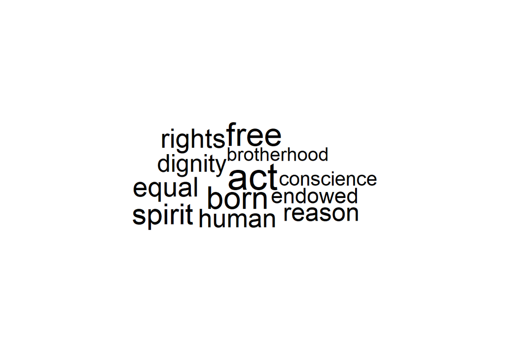

```r
wordcloud_df |>
  ggplot() +
  geom_text_wordcloud_area(aes(label = word, size = n)) +
  scale_size_area(max_size = 20) +
  theme_minimal()
```

**Example**: H.G. Wells’ Time Machine

```r
library(tidyverse)
library(tidytext)
# Download H.G. Wells' Time Machine using gutenbergr package
library(gutenbergr)
time_machine <- gutenberg_download(35)
tidy_time_machine <- time_machine |>
  unnest_tokens(word, text) |>
  anti_join(stop_words)
# word count
time_wordcloud_df <- tidy_time_machine |>
    count(word, sort = TRUE)
time_wordcloud_df
```

```
## # A tibble: 4,172 x 2
##    word          n
##    <chr>     <int>
##  1 time        207
##  2 machine      88
##  3 white        61
##  4 traveller    57
##  5 hand         49
##  6 morlocks     48
##  7 people       46
##  8 weena        46
##  9 found        44
## 10 light        43
## # i 4,162 more rows
```

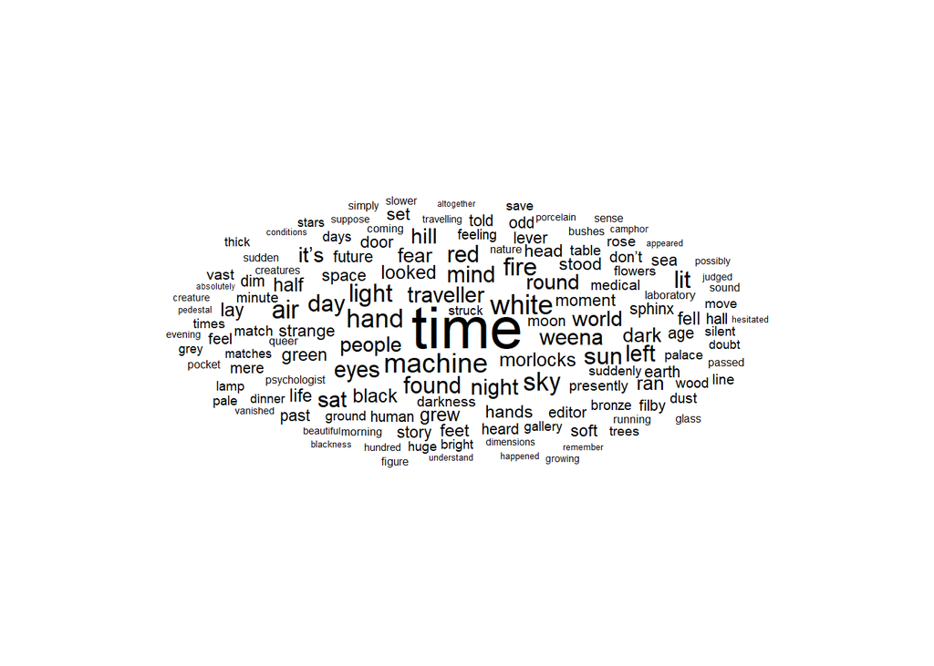

```r
library(ggwordcloud)
set.seed(11) # for reproducibility
time_wordcloud_df |>  filter(n>10) |>
  ggplot() +
  geom_text_wordcloud_area(aes(label = word, size = n)) +
  scale_size_area(max_size = 20) +
  theme_minimal()
```

See below for additional examples.

## 2.4 Sentiment Analysis

In sentiment analysis, we are interested in identifying emotional content of a text. In particular, we aim to understand if a given text or a section of a text can be characterized as positive or negative, or can be classified into certain kinds of emotions. One way to achieve this is to analyze the sentiment content of individual words. In order to do this we need to employ a sentiment lexicon. There are three general-purpose sentiment lexicons in `tidytext` package:

- `AFINN` from [Finn Årup Nielsen](http://www2.imm.dtu.dk/pubdb/views/publication_details.php?id=6010): assigns words with a score that runs between -5 and 5, with negative scores indicating negative sentiment and positive scores indicating positive sentiment.

```r
library(tidytext)
library(textdata)
get_sentiments("afinn")
```

```
## # A tibble: 2,477 x 2
##    word       value
##    <chr>      <dbl>
##  1 abandon       -2
##  2 abandoned     -2
##  3 abandons      -2
##  4 abducted      -2
##  5 abduction     -2
##  6 abductions    -2
##  7 abhor         -3
##  8 abhorred      -3
##  9 abhorrent     -3
## 10 abhors        -3
## # i 2,467 more rows
```

- `bing` from [Bing Liu and collaborators](https://www.cs.uic.edu/~liub/FBS/sentiment-analysis.html): categorizes words in a binary fashion into positive and negative categories.

```r
get_sentiments("bing")
```

```
## # A tibble: 6,786 x 2
##    word        sentiment
##    <chr>       <chr>
##  1 2-faces     negative
##  2 abnormal    negative
##  3 abolish     negative
##  4 abominable  negative
##  5 abominably  negative
##  6 abominate   negative
##  7 abomination negative
##  8 abort       negative
##  9 aborted     negative
## 10 aborts      negative
## # i 6,776 more rows
```

- `nrc` from [Saif Mohammad and Peter Turney](http://saifmohammad.com/WebPages/NRC-Emotion-Lexicon.htm): categorizes words in a binary fashion (“yes”/“no”) into categories of positive, negative, anger, anticipation, disgust, fear, joy, sadness, surprise, and trust.

```r
get_sentiments("nrc")
```

```
## # A tibble: 13,875 x 2
##    word        sentiment
##    <chr>       <chr>
##  1 abacus      trust
##  2 abandon     fear
##  3 abandon     negative
##  4 abandon     sadness
##  5 abandoned   anger
##  6 abandoned   fear
##  7 abandoned   negative
##  8 abandoned   sadness
##  9 abandonment anger
## 10 abandonment fear
## # i 13,865 more rows
```

```r
# sentiment types in nrc lexicon
get_sentiments("nrc") |>
  group_by(sentiment) |>
  summarise(n = n()) |>
  arrange(desc(n))
```

```
## # A tibble: 10 x 2
##    sentiment        n
##    <chr>        <int>
##  1 negative      3318
##  2 positive      2308
##  3 fear          1474
##  4 anger         1246
##  5 trust         1230
##  6 sadness       1187
##  7 disgust       1056
##  8 anticipation   837
##  9 joy            687
## 10 surprise       532
```

```r
nrc_positive <- get_sentiments("nrc") |>
  filter(sentiment == "positive")
nrc_positive
```

```
## # A tibble: 2,308 x 2
##    word           sentiment
##    <chr>          <chr>
##  1 abba           positive
##  2 ability        positive
##  3 abovementioned positive
##  4 absolute       positive
##  5 absolution     positive
##  6 absorbed       positive
##  7 abundance      positive
##  8 abundant       positive
##  9 academic       positive
## 10 academy        positive
## # i 2,298 more rows
```

Example: Count the positive words in `text_data_tidy` which was previously created above:

```r
text_data_tidy |>  inner_join(nrc_positive) |>
  count(word, sort = TRUE)
```

```
## # A tibble: 6 x 2
##   word            n
##   <chr>       <int>
## 1 brotherhood     1
## 2 conscience      1
## 3 dignity         1
## 4 endowed         1
## 5 reason          1
## 6 spirit          1
```

Example: Time Machine

```r
time_machine_sentiment <- tidy_time_machine |>
  # find a sentiment score for each word using bing lexicon
  inner_join(get_sentiments("bing"))
# count sentiment
time_machine_sentiment |>
  count(sentiment)
```

```
## # A tibble: 2 x 2
##   sentiment     n
##   <chr>     <int>
## 1 negative   1347
## 2 positive    638
```

```r
# sentiment types in nrc lexicon
time_machine_sentiment_nrc <- tidy_time_machine |>
  inner_join(get_sentiments("nrc"))
time_machine_sentiment_nrc
```

```
## # A tibble: 6,787 x 3
##    gutenberg_id word    sentiment
##           <int> <chr>   <chr>
##  1           35 time    anticipation
##  2           35 machine trust
##  3           35 machine trust
##  4           35 time    anticipation
##  5           35 time    anticipation
##  6           35 sunset  anticipation
##  7           35 sunset  positive
##  8           35 sudden  surprise
##  9           35 shock   anger
## 10           35 shock   fear
## # i 6,777 more rows
```

```r
time_machine_sentiment_nrc |>
  group_by(sentiment) |>
  summarise(n = n()) |>
  arrange(desc(n))
```

```
## # A tibble: 10 x 2
##    sentiment        n
##    <chr>        <int>
##  1 positive      1257
##  2 negative      1129
##  3 trust          759
##  4 anticipation   743
##  5 fear           702
##  6 sadness        577
##  7 joy            543
##  8 anger          428
##  9 surprise       349
## 10 disgust        300
```

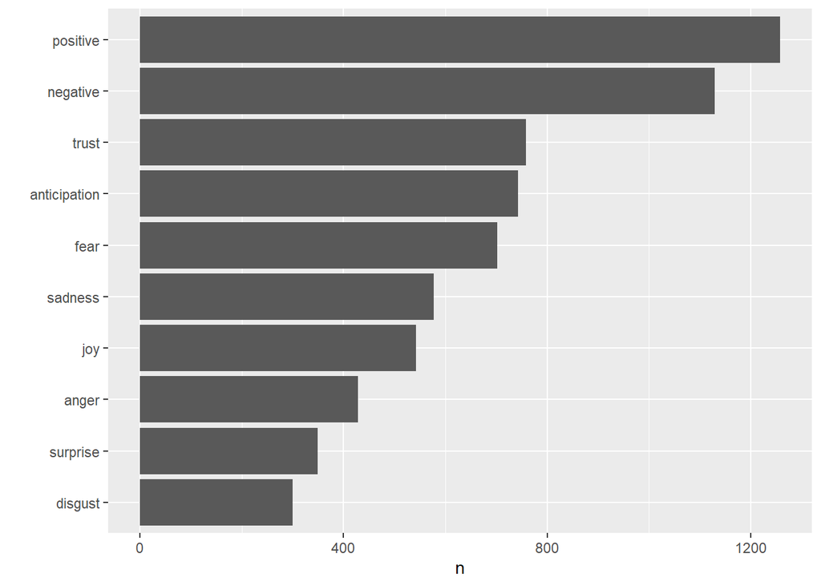

```r
time_machine_sentiment_nrc |>
  group_by(sentiment) |>
  summarise(n = n()) |>
  ggplot(aes(fct_reorder(sentiment, n),n)) +
  geom_bar(stat="identity") +
  coord_flip() +
  xlab("")
```

## 2.5 Word importance: tf.idf

The frequency of a word or **term frequency** (tf) is a measure of how important a word is in a document. In English as well as in other languages there are several words that may not be important on their own (the, is, a, etc.). Removing these so-called stopwords from the document before the analysis is one way to measure the importance of words. Another way is to compute **tf idf** (term frequency inverse document frequency) statistic.

Inverse document frequency (**idf**) puts smaller weights on commonly used words in a document but increases the weight of less commonly used ones (so, the closer the idf to zero, the more common a word is). Multiplying **tf** (number of times a word appears in a document) by **idf**, we obtain the **tf.idf** statistic which measures how relevant a word is to a document in a collection of documents (for example, to one novel in a collection of novels or to one website in a collection of websites, see Silge, Text Mining with R).

**idf** can be computed using

$$idf(\text{term}) =
\ln{\left(\frac{n_{\text{documents}}}{n_{\text{documents containing
term}}}\right)}$$

where the numerator $n_{\text{documents}}$ is the number of documents in the corpus and the denominator is the number of documents containing the term. For example, if there are 5 documents in the corpus and a given word is contained in all of them then $idf$ will be $0$. If a word is only contained in one of the documents then $idf=\ln(5/1)\approx 1.61$.

# 3 Example: Text Analysis of Jane Austen’s Books

This example is from Text Mining with R (by Julia Silge and David Robinson). For more details on the preprocessing please visit https://www.tidytextmining.com/tidytext.html#tidyausten.

```r
# Jane Austin's books
# This is an example from Julia silge's book
# load data
load("../Data/j_austen_books_tidy.rda")
```

## 3.1 Frequent words

Remove stop words:

```r
data(stop_words)

j_austen_books_tidy <- j_austen_books_tidy |>
  anti_join(stop_words)
```

Count word frequency:

```r
j_austen_books_tidy |>
  count(word, sort = TRUE)
```

```
## # A tibble: 13,914 x 2
##    word       n
##    <chr>  <int>
##  1 miss    1855
##  2 time    1337
##  3 fanny    862
##  4 dear     822
##  5 lady     817
##  6 sir      806
##  7 day      797
##  8 emma     787
##  9 sister   727
## 10 house    699
## # i 13,904 more rows
```

Bar graph using ggplot:

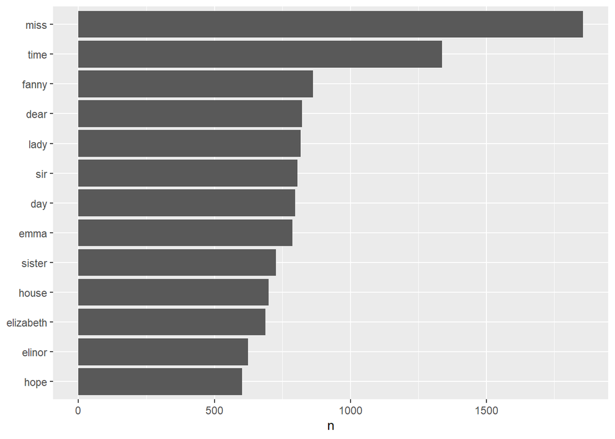

```r
j_austen_books_tidy |>
  count(word, sort = TRUE) |>
  filter(n > 600) |>
  mutate(word = reorder(word, n)) |>
  ggplot(aes(n, word)) +
  geom_col() +
  labs(y = NULL)
```

Display the most frequent words (n>300) over books:

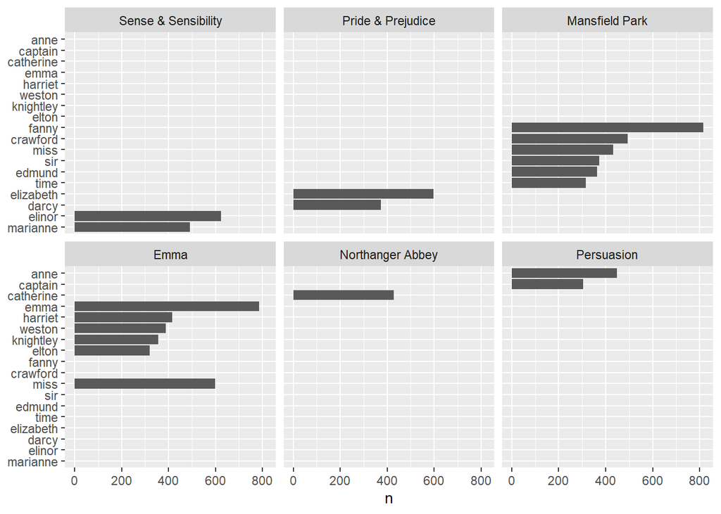

```r
j_austen_books_tidy |>
  group_by(book) |>
  count(word, sort = TRUE) |>
  filter(n > 300) |>
  mutate(word = reorder(word, n)) |>
  ggplot(aes(n, word)) +
  geom_col() + facet_wrap(~book) +
  labs(y = NULL) +
  theme(legend.position="none")
```

Graph the most frequently used (n>100) words in Sense and Sensibility:

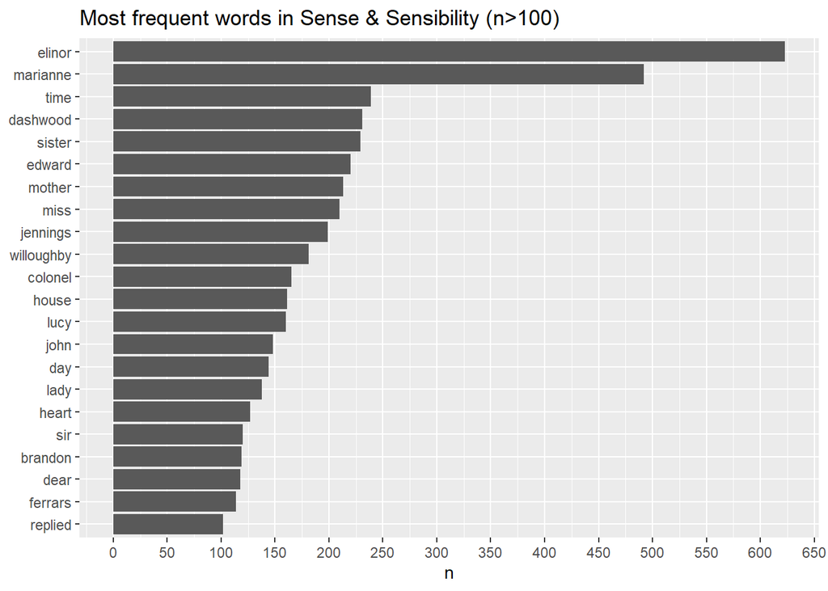

```r
j_austen_books_tidy |>
  filter(book == "Sense & Sensibility") |>
  count(word, sort = TRUE) |>
  filter(n > 100) |>
  mutate(word = reorder(word, n)) |>
  ggplot(aes(n, word)) +
  geom_col() +
  scale_x_continuous(breaks = seq(0,650,50)) +
  labs(y = NULL,
       title = "Most frequent words in Sense & Sensibility (n>100)")
```

## 3.2 Word Clouds

All 6 books together:

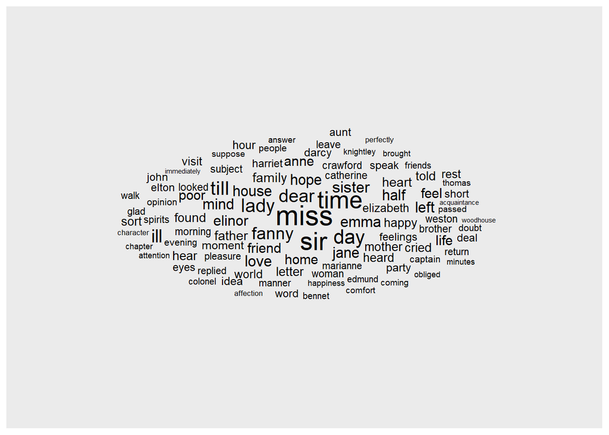

```r
library(ggwordcloud)
wordcloud_df <-j_austen_books_tidy |>
  count(word, sort = T) |>
  top_n(100)

wordcloud_df |>
  ggplot() +
  geom_text_wordcloud_area(aes(label = word, size = n)) +
  scale_size_area(max_size = 15)
```

By books:

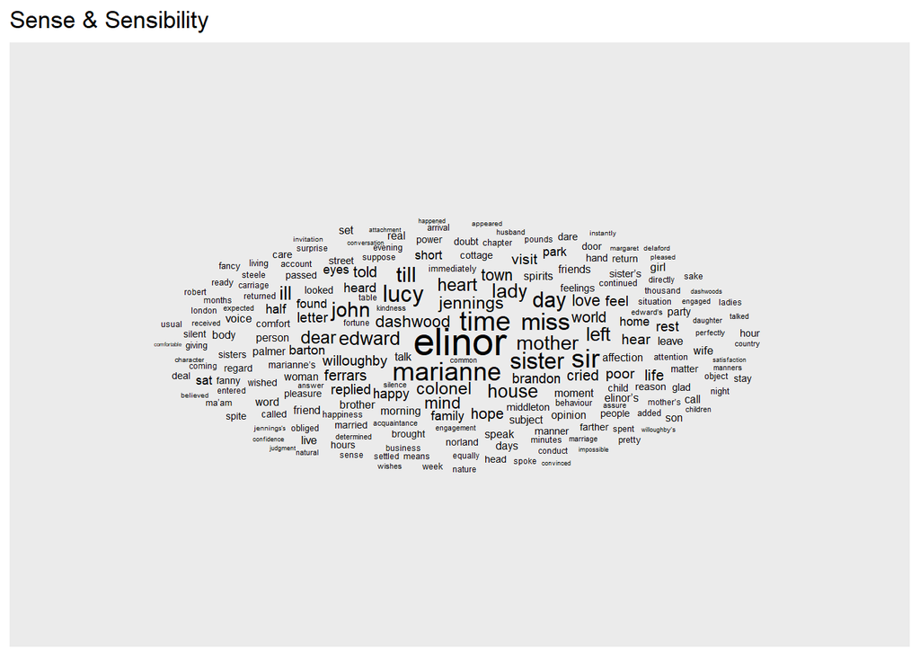

```r
n <- 200
p1 <-j_austen_books_tidy |>
  filter(book=="Sense & Sensibility") |>
  count(word, sort = T) |>
  slice_max(n, n=n) |>
  ggplot() +
  geom_text_wordcloud_area(aes(label = word, size = n)) +
  scale_size_area(max_size = 15) +
  labs(title = "Sense & Sensibility")
p1
```

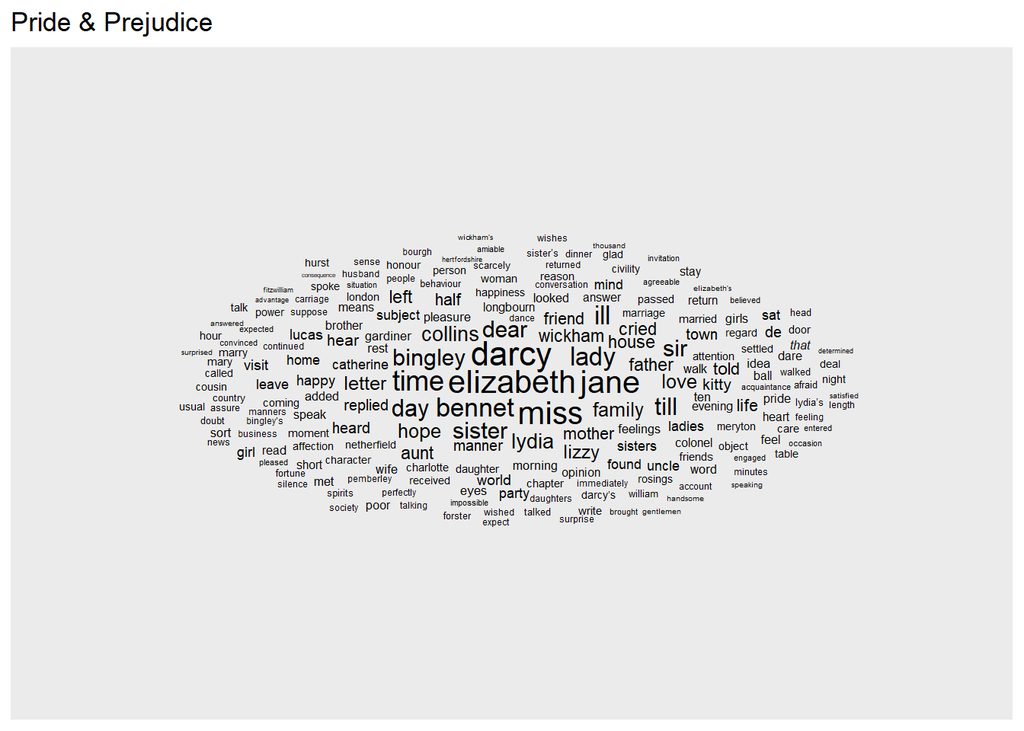

```r
#
p2 <-j_austen_books_tidy |>
  filter(book=="Pride & Prejudice") |>
  count(word, sort = T) |>
  slice_max(n, n=n) |>
  ggplot() +
  geom_text_wordcloud_area(aes(label = word, size = n)) +
  scale_size_area(max_size = 15) +
  labs(title = "Pride & Prejudice")
p2
```

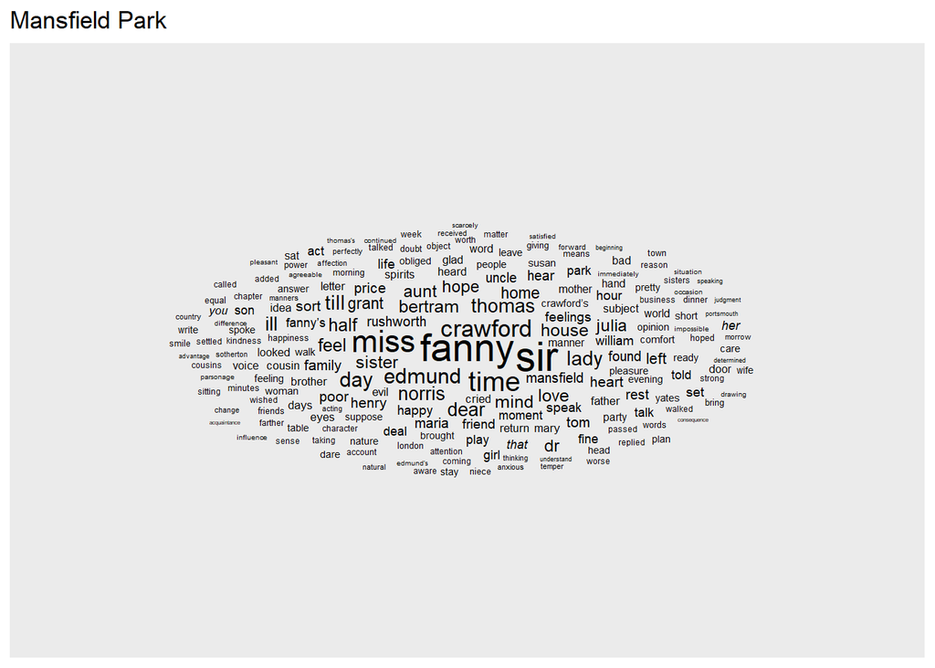

```r
#
p3 <-j_austen_books_tidy |>
  filter(book=="Mansfield Park") |>
  count(word, sort = T) |>
  slice_max(n, n=n) |>
  ggplot() +
  geom_text_wordcloud_area(aes(label = word, size = n)) +
  scale_size_area(max_size = 15) +
  labs(title = "Mansfield Park")
p3
```

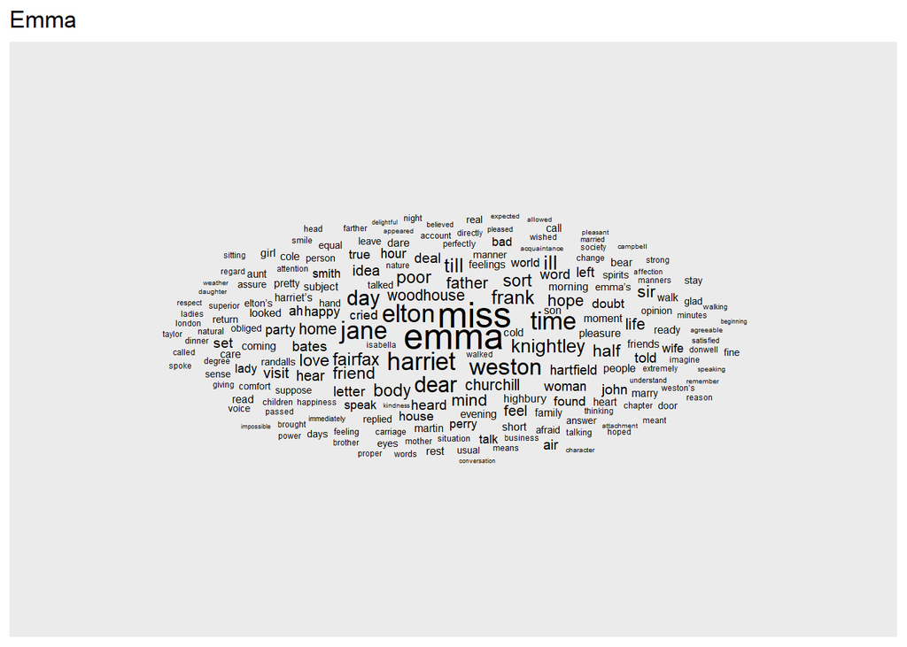

```r
#
p4 <-j_austen_books_tidy |>
  filter(book=="Emma") |>
  count(word, sort = T) |>
  slice_max(n, n=n) |>
  ggplot() +
  geom_text_wordcloud_area(aes(label = word, size = n)) +
  scale_size_area(max_size = 15) +
  labs(title = "Emma")
p4
```

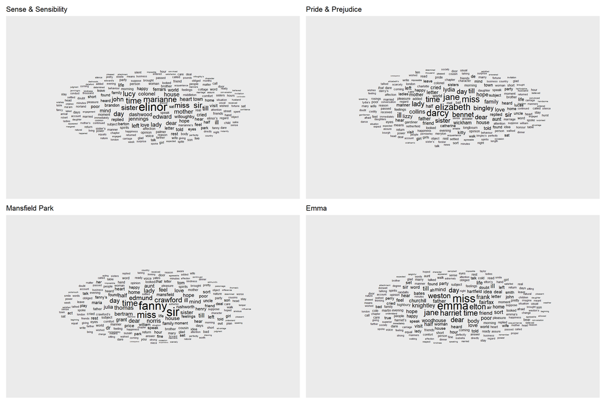

```r
library(patchwork)
p1 + p2 + p3 + p4
```

## 3.3 Sentiment Analysis

Examining how sentiment changes across J. Austen’s books (this example is from J. Silge’s text.)

```r
jane_austen_sentiment <- j_austen_books_tidy |>
  # find a sentiment score for each word using bing lexicon
  inner_join(get_sentiments("bing")) |>
  # count up how many positive and negative words there are
  # in sections of 80 lines of text.
  count(book, index = linenumber %/% 80, sentiment) |>
  # convert to wide format
  pivot_wider(names_from = sentiment, values_from = n, values_fill = 0) |>
  # compute net sentiment score
  mutate(sentiment = positive - negative)
head(jane_austen_sentiment)
```

```
## # A tibble: 6 x 5
##   book                index negative positive sentiment
##   <fct>               <dbl>    <int>    <int>     <int>
## 1 Sense & Sensibility     0       16       26        10
## 2 Sense & Sensibility     1       19       44        25
## 3 Sense & Sensibility     2       12       23        11
## 4 Sense & Sensibility     3       15       22         7
## 5 Sense & Sensibility     4       16       29        13
## 6 Sense & Sensibility     5       16       39        23
```

Note that there are 12620 lines in Sense & Sensibility which gives us about 157 sections of 80 lines. Here is the graph of emotional content per book:

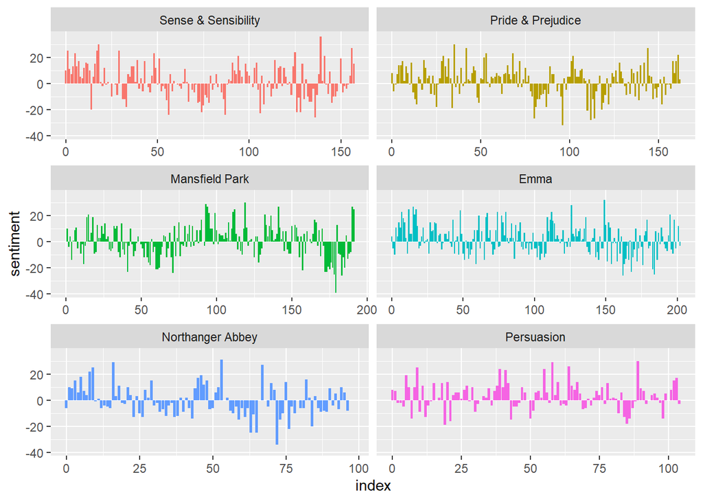

```r
ggplot(jane_austen_sentiment, aes(index, sentiment, fill = book)) +
  geom_col(show.legend = FALSE) +
  facet_wrap(~book, ncol = 2, scales = "free_x")
```

## 3.4 Word imortance: tf.idf

**Example**: J. Austen’s books (from J. Silge’s text)

```r
# Jane Austin's books
# This is an example from Julia silge's book
library(dplyr)
library(janeaustenr)
library(tidytext)

book_words <- austen_books() |>
  unnest_tokens(word, text) |>
  count(book, word, sort = TRUE)

total_words <- book_words |>
  group_by(book) |>
  summarize(total = sum(n))

book_words <- left_join(book_words, total_words)

book_words
```

```
## # A tibble: 40,379 x 4
##    book              word      n  total
##    <fct>             <chr> <int>  <int>
##  1 Mansfield Park    the    6206 160460
##  2 Mansfield Park    to     5475 160460
##  3 Mansfield Park    and    5438 160460
##  4 Emma              to     5239 160996
##  5 Emma              the    5201 160996
##  6 Emma              and    4896 160996
##  7 Mansfield Park    of     4778 160460
##  8 Pride & Prejudice the    4331 122204
##  9 Emma              of     4291 160996
## 10 Pride & Prejudice to     4162 122204
## # i 40,369 more rows
```

Plot term frequency (tf = n/total):

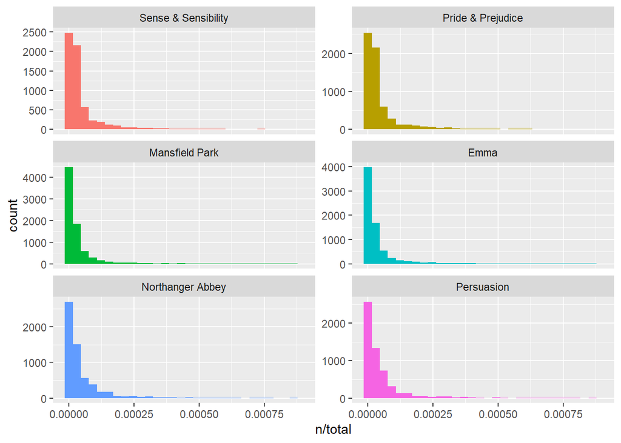

```r
library(ggplot2)

ggplot(book_words, aes(n/total, fill = book)) +
  geom_histogram(show.legend = FALSE) +
  xlim(NA, 0.0009) +
  facet_wrap(~book, ncol = 2, scales = "free_y")
```

```r
# long right tail is truncated at 0.0009
```

Compute tf-idf:

```r
book_tf_idf <- book_words |>
  bind_tf_idf(word, book, n)

book_tf_idf
```

```
## # A tibble: 40,379 x 7
##    book              word      n  total     tf   idf tf_idf
##    <fct>             <chr> <int>  <int>  <dbl> <dbl>  <dbl>
##  1 Mansfield Park    the    6206 160460 0.0387     0      0
##  2 Mansfield Park    to     5475 160460 0.0341     0      0
##  3 Mansfield Park    and    5438 160460 0.0339     0      0
##  4 Emma              to     5239 160996 0.0325     0      0
##  5 Emma              the    5201 160996 0.0323     0      0
##  6 Emma              and    4896 160996 0.0304     0      0
##  7 Mansfield Park    of     4778 160460 0.0298     0      0
##  8 Pride & Prejudice the    4331 122204 0.0354     0      0
##  9 Emma              of     4291 160996 0.0267     0      0
## 10 Pride & Prejudice to     4162 122204 0.0341     0      0
## # i 40,369 more rows
```

Common and unimportant words have zero tfidf values.

```r
book_tf_idf |>
  select(-total) |>
  arrange(desc(tf_idf))
```

```
## # A tibble: 40,379 x 6
##    book                word          n      tf   idf  tf_idf
##    <fct>               <chr>     <int>   <dbl> <dbl>   <dbl>
##  1 Sense & Sensibility elinor      623 0.00519  1.79 0.00931
##  2 Sense & Sensibility marianne    492 0.00410  1.79 0.00735
##  3 Mansfield Park      crawford    493 0.00307  1.79 0.00551
##  4 Pride & Prejudice   darcy       373 0.00305  1.79 0.00547
##  5 Persuasion          elliot      254 0.00304  1.79 0.00544
##  6 Emma                emma        786 0.00488  1.10 0.00536
##  7 Northanger Abbey    tilney      196 0.00252  1.79 0.00452
##  8 Emma                weston      389 0.00242  1.79 0.00433
##  9 Pride & Prejudice   bennet      294 0.00241  1.79 0.00431
## 10 Persuasion          wentworth   191 0.00228  1.79 0.00409
## # i 40,369 more rows
```

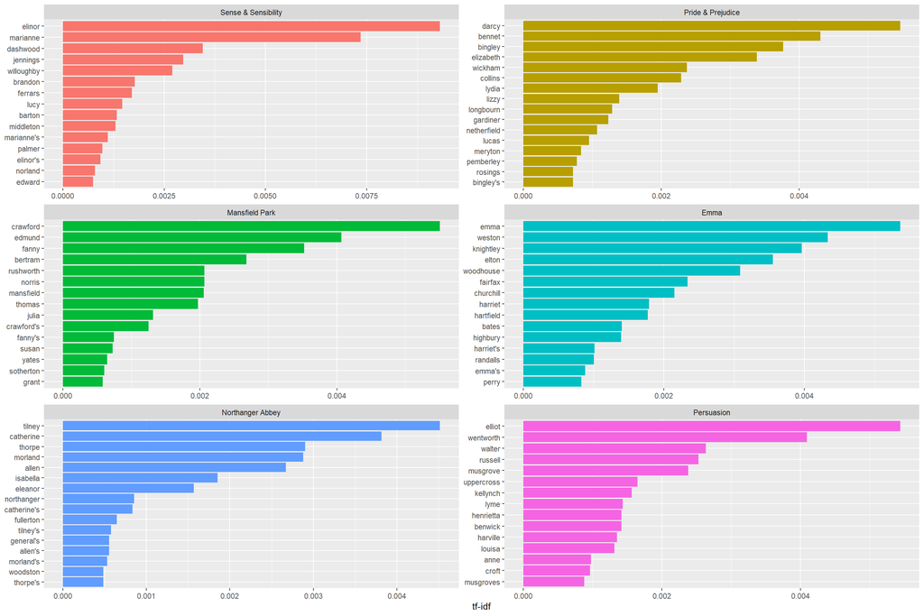

```r
library(forcats)

book_tf_idf |>
  group_by(book) |>
  slice_max(tf_idf, n = 15) |>
  ungroup() |>
  ggplot(aes(tf_idf, fct_reorder(word, tf_idf), fill = book)) +
  geom_col(show.legend = FALSE) +
  facet_wrap(~book, ncol = 2, scales = "free") +
  labs(x = "tf-idf", y = NULL)
```

The most important terms in these novels are the names of people and places.

# 4 Example: FOMC meetings

## 4.1 Prepare the data

```r
library(tidyverse)
library(tidytext)
library(stopwords)
library(textreadr)

fomc_2017 <- textreadr::read_docx("../Data/FOMC (04.2017).docx")
fomc_2020 <- textreadr::read_docx("../Data/FOMC (03.2020).docx")
```

```r
# single character
fomc_2017 <- paste(fomc_2017, collapse = ' ')

# put them in a tibble
fomc_2017 <- tibble(year=2017, text=fomc_2017)
```

```r
# tidy text: text data must be be one word in each row format
fomc_2017_tidy <- fomc_2017 |>
  unnest_tokens(word, text) |>
  filter(is.na(as.numeric(word))) # remove numbers
```

```r
# do the same for 2020
# single character
fomc_2020 <- paste(fomc_2020, collapse = ' ')

# put them in a tibble
fomc_2020 <- tibble(year=2020, text=fomc_2020)

# tidy text: text data must be be one word in each row format
fomc_2020_tidy <- fomc_2020 |>
  unnest_tokens(word, text) |>
  filter(is.na(as.numeric(word))) # remove numbers
```

We can also combine these two data set into single corpus:

```r
fomc_tidy <- rbind(fomc_2017_tidy, fomc_2020_tidy)
# could use full_join() as well
# fomc_tidy <- full_join(fomc_2017_tidy, fomc_2020_tidy)
```

## 4.2 Word frequency

```r
# count how many times each word is used in 2017
fomc_2017_tidy |>
  count(word, sort = TRUE)
```

```
## # A tibble: 355 x 2
##    word          n
##    <chr>     <int>
##  1 the          66
##  2 to           37
##  3 of           36
##  4 and          31
##  5 in           22
##  6 federal      21
##  7 market       16
##  8 committee    15
##  9 inflation    13
## 10 rate         13
## # i 345 more rows
```

```r
# remove stopwords
fomc_2017_tidy |>
  anti_join(get_stopwords()) |>
  count(word, sort=TRUE)
```

```
## # A tibble: 309 x 2
##    word           n
##    <chr>      <int>
##  1 federal       21
##  2 market        16
##  3 committee     15
##  4 inflation     13
##  5 rate          13
##  6 open          10
##  7 percent       10
##  8 policy        10
##  9 securities     9
## 10 funds          8
## # i 299 more rows
```

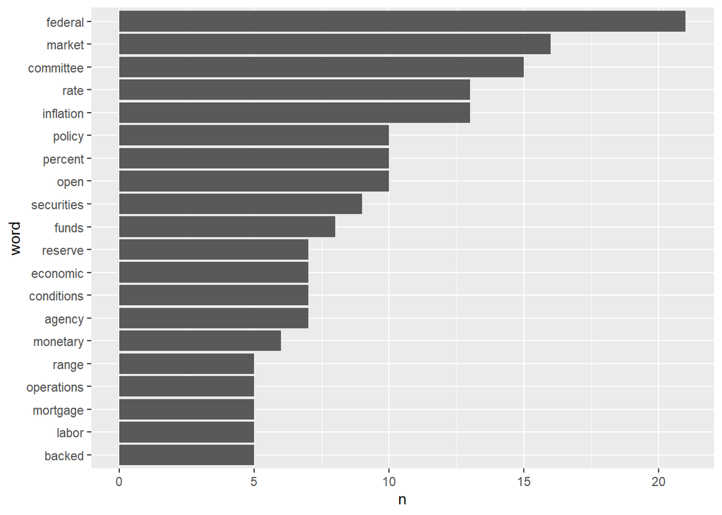

```r
# visualize top words in 2017
fomc_2017_tidy |>
  # remove stop words
  anti_join(get_stopwords()) |>
  count(word, sort = TRUE) |>
  slice_max(n, n = 20) |>
  mutate(word = reorder(word, n)) |>
  # put `n` on the x-axis and `word` on the y-axis
  ggplot(aes(x = n, y = word)) +
  geom_col()
```

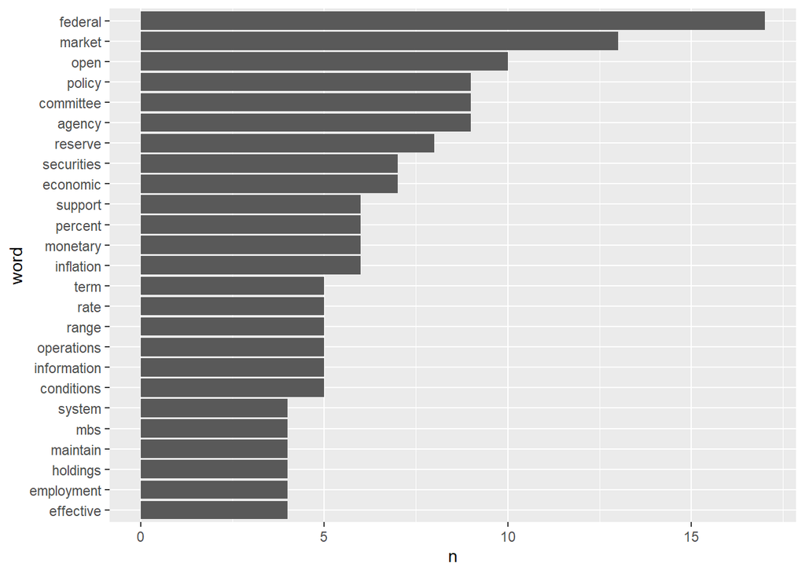

```r
# visualize top words in 2020
fomc_2020_tidy |>
  # remove stop words
  anti_join(get_stopwords()) |>
  count(word, sort = TRUE) |>
  slice_max(n, n = 20) |>
  mutate(word = reorder(word, n)) |>
  # put `n` on the x-axis and `word` on the y-axis
  ggplot(aes(x = n, y = word)) +
  geom_col()
```

## 4.3 Wordclouds

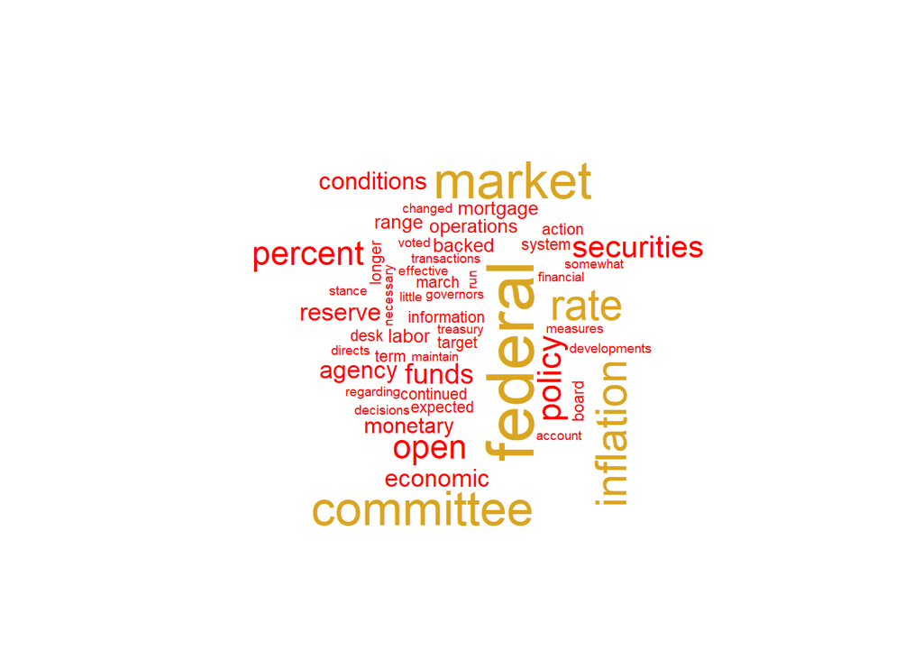

```r
# wordcloud
high_freq_terms <- fomc_2017_tidy |>
  anti_join(get_stopwords()) |>
  count(word, sort=TRUE)

library(wordcloud)
wordcloud(high_freq_terms$word,
          high_freq_terms$n,
          colors = c("red","goldenrod"),
          scale = c(3,0.2))
```

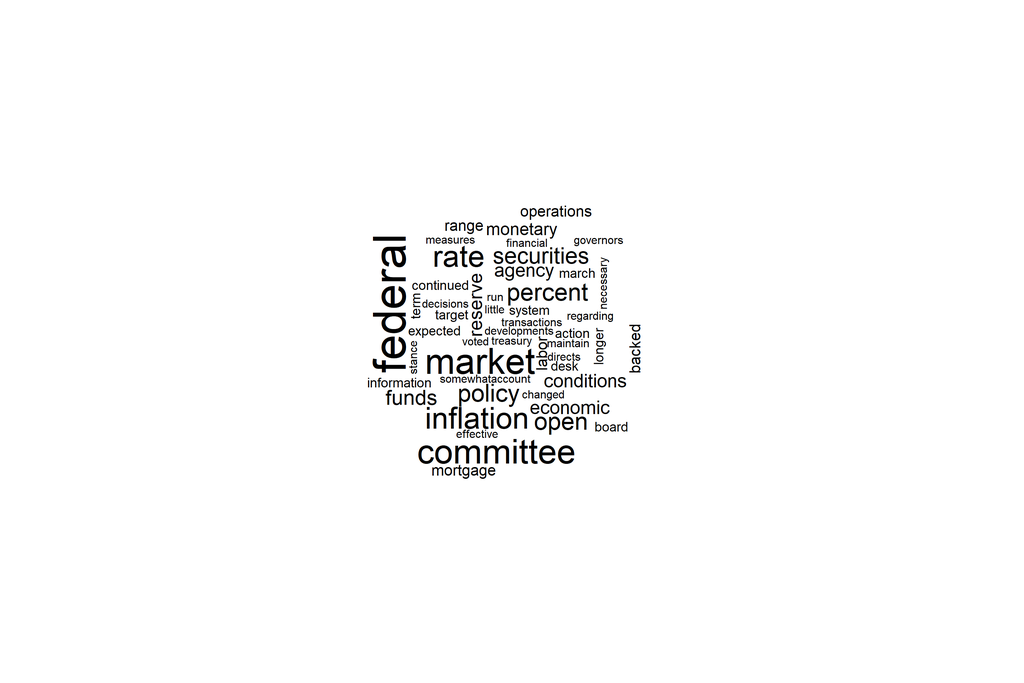

```r
fomc_2017_tidy |>
  anti_join(get_stopwords()) |>
  count(word) |>
  with(wordcloud(word, n, max.words = 500))
```

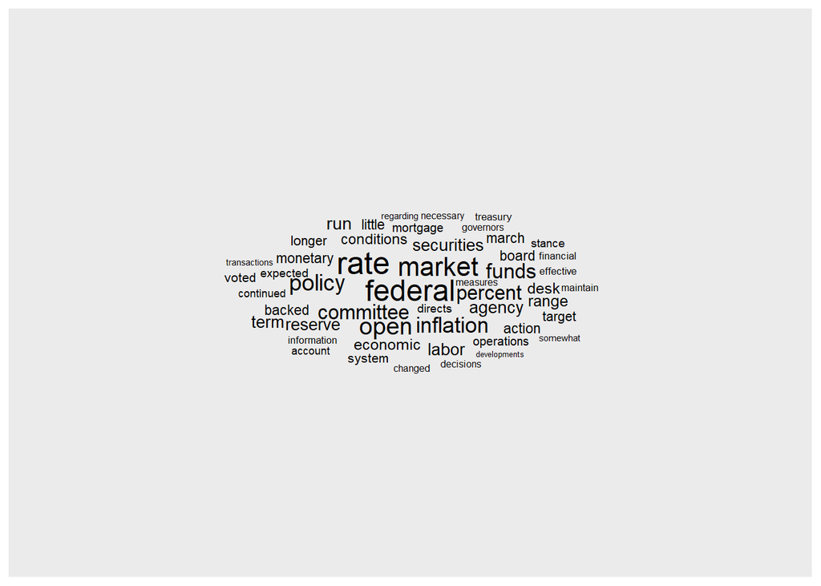

```r
# alternatively
library(ggwordcloud)
wordcloud_df <-fomc_2017_tidy |>
  anti_join(get_stopwords()) |>
  count(word, sort = T) |>
  top_n(50)

wordcloud_df |>
  ggplot() +
  geom_text_wordcloud_area(aes(label = word, size = n)) +
  scale_size_area(max_size = 15)
```

## 4.4 Sentiment Analysis

Count the number of positive and negative words

```r
library(ggwordcloud)

wordcloud_df_2017 <- fomc_2017_tidy |>
  anti_join(get_stopwords()) |>
  inner_join(get_sentiments("bing")) |>
  count(sentiment, word, sort = T) |>
  top_n(100)
wordcloud_df_2017
```

```
## # A tibble: 19 x 3
##    sentiment word              n
##    <chr>     <chr>         <int>
##  1 positive  effective         3
##  2 negative  debt              2
##  3 positive  accommodative     2
##  4 negative  limit             1
##  5 negative  limited           1
##  6 negative  risks             1
##  7 negative  vice              1
##  8 positive  appropriate       1
##  9 positive  approve           1
## 10 positive  available         1
## 11 positive  balanced          1
## 12 positive  consistent        1
## 13 positive  facilitate        1
## 14 positive  gains             1
## 15 positive  solid             1
## 16 positive  stability         1
## 17 positive  stabilize         1
## 18 positive  supporting        1
## 19 positive  well              1
```

```r
wordcloud_df_2017 |>
  group_by(sentiment) |>
  summarise(n=n())
```

```
## # A tibble: 2 x 2
##   sentiment     n
##   <chr>     <int>
## 1 negative      5
## 2 positive     14
```

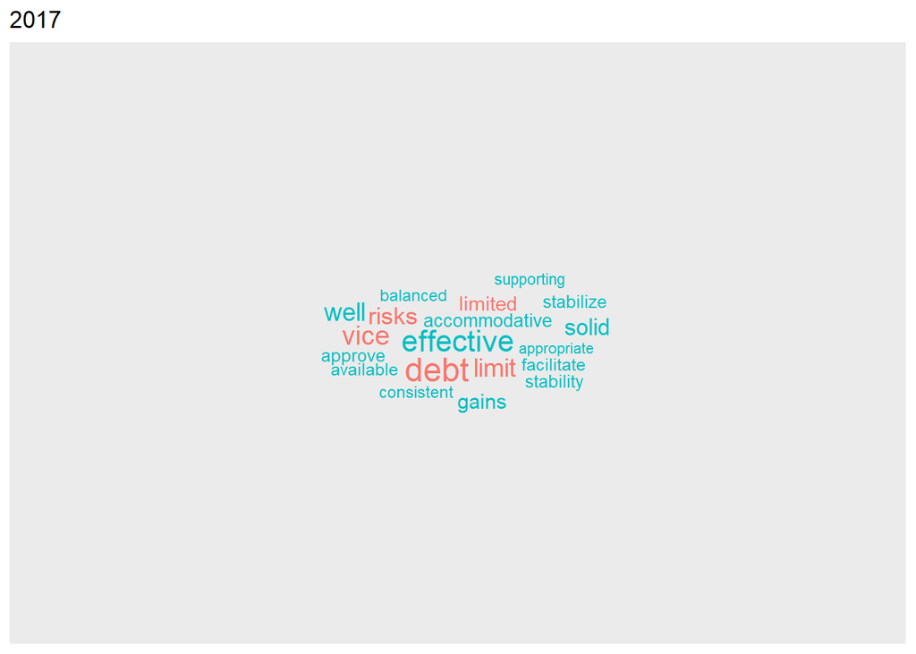

```r
wordcloud_df_2017 |>
  ggplot() +
  geom_text_wordcloud_area(aes(label = word, size = n, color=sentiment)) +
  scale_size_area(max_size = 15) +
  labs(title = "2017")
```

```r
# 2020
wordcloud_df_2020 <-fomc_2020_tidy |>
  anti_join(get_stopwords()) |>
  inner_join(get_sentiments("bing")) |>
  count(sentiment, word, sort = T) |>
  top_n(100)
wordcloud_df_2020
```

```
## # A tibble: 24 x 3
##    sentiment word            n
##    <chr>     <chr>       <int>
##  1 positive  support         6
##  2 positive  effective       4
##  3 positive  appropriate     3
##  4 positive  smooth          3
##  5 negative  limit           2
##  6 positive  stability       2
##  7 negative  challenging     1
##  8 negative  crisis          1
##  9 negative  debt            1
## 10 negative  declines        1
## # i 14 more rows
```

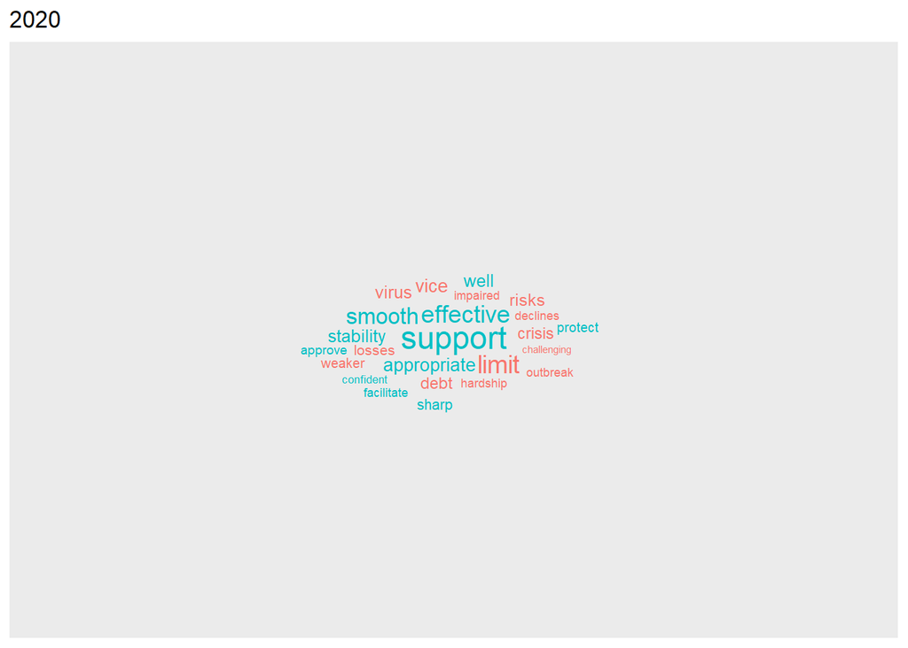

```r
wordcloud_df_2020 |>
  ggplot() +
  geom_text_wordcloud_area(aes(label = word, size = n, color=sentiment)) +
  scale_size_area(max_size = 15) +
  labs(title = "2020")
```

Compared to 2017, we see new negative words in 2020 such as virus, hardship, crisis, and outbreak. The words support, effective, and stability are still important but support has the highest frequency.

Compare negative and positive words using comparison clouds:

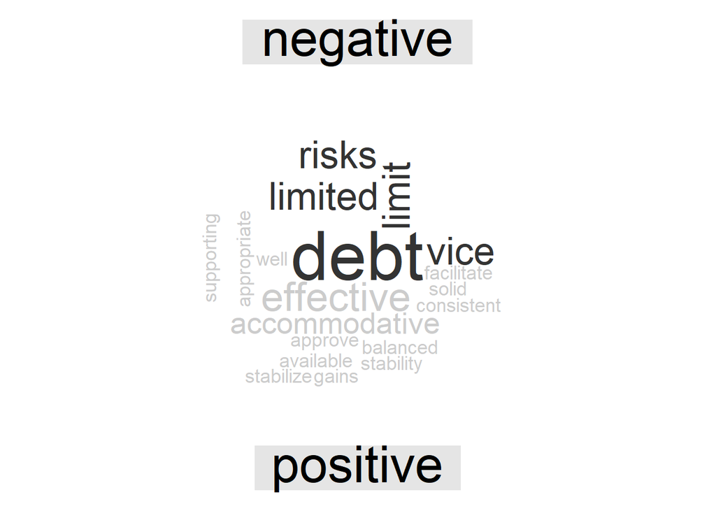

```r
library(wordcloud)

fomc_2017_tidy |>
  inner_join(get_sentiments("bing")) |>
  count(word, sentiment, sort = TRUE) |>
  reshape2::acast(word ~ sentiment, value.var = "n", fill = 0) |>
  comparison.cloud(colors = c("gray20", "gray80"),
                   max.words = 100)
```

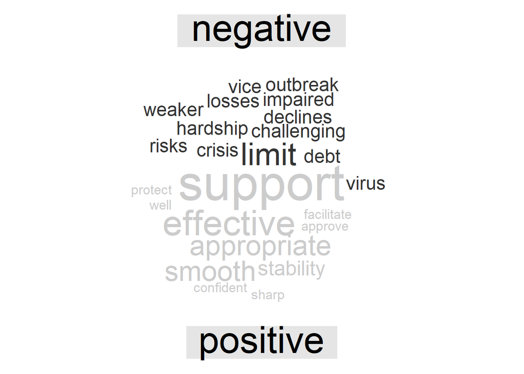

```r
fomc_2020_tidy |>
  inner_join(get_sentiments("bing")) |>
  count(word, sentiment, sort = TRUE) |>
  reshape2::acast(word ~ sentiment, value.var = "n", fill = 0) |>
  comparison.cloud(colors = c("gray20", "gray80"),
                   max.words = 100)
```

tf-idf analysis:

```r
# count the frequency of each word
# and add total words in each document (year)
fomc_words <- fomc_tidy |>
  add_count(year, name = "total_words") |>
  group_by(year, total_words) |>
  count(word, sort = TRUE) |>
  ungroup()
#
fomc_words
```

```
## # A tibble: 663 x 4
##     year total_words word        n
##    <dbl>       <int> <chr>   <int>
##  1  2017         908 the        66
##  2  2020         804 the        65
##  3  2020         804 and        40
##  4  2017         908 to         37
##  5  2017         908 of         36
##  6  2020         804 to         35
##  7  2020         804 of         34
##  8  2017         908 and        31
##  9  2017         908 in         22
## 10  2017         908 federal    21
## # i 653 more rows
```

Inspect the distribution of `n/total` in `fomc_words`:

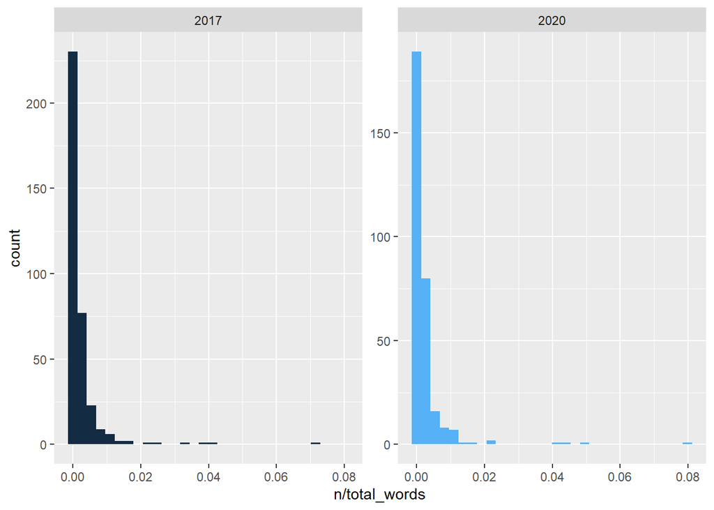

```r
ggplot(fomc_words) +
  geom_histogram(aes(n / total_words, fill = year), show.legend = FALSE) +
  facet_wrap(~ year, nrow = 1, scales = "free_y")
```

Use `tidytext::bind_tf_idf()` function:

```r
fomc_words_idf <- fomc_words |>
  select(-total_words) |>
  bind_tf_idf(term = word, document = year, n = n)
fomc_words_idf
```

```
## # A tibble: 663 x 6
##     year word        n     tf   idf tf_idf
##    <dbl> <chr>   <int>  <dbl> <dbl>  <dbl>
##  1  2017 the        66 0.0727     0      0
##  2  2020 the        65 0.0808     0      0
##  3  2020 and        40 0.0498     0      0
##  4  2017 to         37 0.0407     0      0
##  5  2017 of         36 0.0396     0      0
##  6  2020 to         35 0.0435     0      0
##  7  2020 of         34 0.0423     0      0
##  8  2017 and        31 0.0341     0      0
##  9  2017 in         22 0.0242     0      0
## 10  2017 federal    21 0.0231     0      0
## # i 653 more rows
```

Notice that `tf_idf` is practically zero for the most common words (such as the, and, to, of, etc.). We could remove these stopwords before the analysis but here we kept them to demonstrate that these will be essentially zero.

```r
fomc_words_idf |>
  arrange(desc(tf_idf))
```

```
## # A tibble: 663 x 6
##     year word            n      tf   idf  tf_idf
##    <dbl> <chr>       <int>   <dbl> <dbl>   <dbl>
##  1  2020 support         6 0.00746 0.693 0.00517
##  2  2020 mbs             4 0.00498 0.693 0.00345
##  3  2017 continued       4 0.00441 0.693 0.00305
##  4  2017 longer          4 0.00441 0.693 0.00305
##  5  2017 march           4 0.00441 0.693 0.00305
##  6  2020 agreement       3 0.00373 0.693 0.00259
##  7  2020 april           3 0.00373 0.693 0.00259
##  8  2020 cmbs            3 0.00373 0.693 0.00259
##  9  2020 economy         3 0.00373 0.693 0.00259
## 10  2020 functioning     3 0.00373 0.693 0.00259
## # i 653 more rows
```

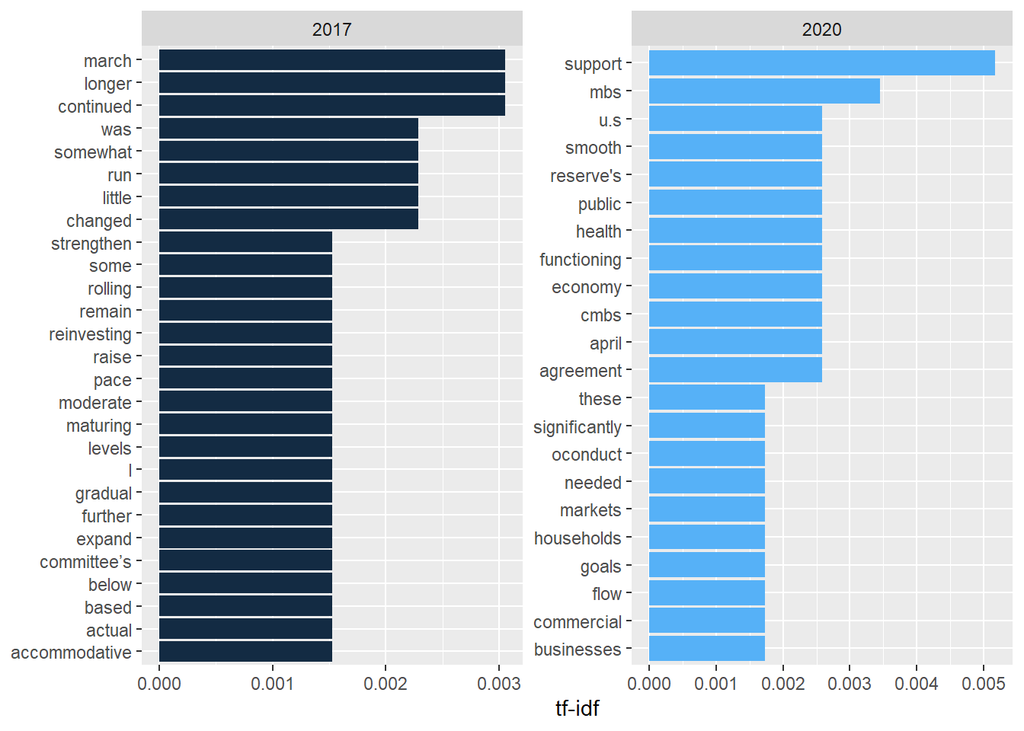

```r
library(forcats)

fomc_words_idf |>
  group_by(year) |>
  slice_max(tf_idf, n = 15) |>
  ungroup() |>
  ggplot(aes(tf_idf, fct_reorder(word, tf_idf), fill = year)) +
  geom_col(show.legend = FALSE) +
  facet_wrap(~ year, ncol = 2, scales = "free") +
  labs(x = "tf-idf", y = NULL)
```